# HW3 - Data wrangling and simple modeling with R

Keith Salach

November 2, 2019

## Step 1 - Familiarize yourself with the data and the assignment

In this assignment you’ll do some exploratory data analysis with R on a dataset about airline flights into and out of of Detroit Metropolitan Airport during January of 2017. See the README.md file (it’s just a plain text file with markdown in it) for details about the data file.

You’ll be doing your work right in this R Markdown document to do some data wrangling, analysis and model building as well as to document the steps you did (and answer some questions I’ll throw at you).

You’ll notice a few “Hacker Extra” tasks thrown in at the end. These are for those of you who want to go a little above and beyond and attempt some more challenging tasks. And, feel free to do a some free form Hacker Extra style work yourself - in other words, do something beyond what was asked. You’ll learn more.

## Step 2 - Create a new R Markdown document

Save this R Markdown document with a new name - name it **HW3_wrangling_lm_[*your last name*].Rmd**. Mine would be called **HW3_wrangling_lm_isken.Rmd**. Save it into the same folder as this assignment.

## Step 3 - Create R project and explore data folder

Create an R project based on the folder containing this file. You’ll notice that there is a folder named **data**. Inside of it you’ll find the data file for this assignment - **flights_mi_2017.csv** as well as a few other data files. You’ll also find an folder named **images** that contains, well, images.

## Step 4 - Complete the following R tasks and answer questions

Now you’ll need to complete the following tasks in R. Just like we did in class, you should use a combination of markdown text (be concise, no need to write tons of text) to explain what you are doing and R code chunks to actually do it. When you are done, use the “Knit” button to generate an HTML file from your R Markdown. You’ll be submitting BOTH the completed R Markdown file as well as the generated HTML file. Just like in the previous homework, you’ll simply be compressing your entire project folder and uploading that into Moodle.

**HINT: I highly recommend skimming through the entire document before starting.**

Let’s load a few libraries we’ll need:

```r
library(dplyr)
```

```r
library(ggplot2)
library(stringr)
library(lubridate)
library(readr)
library(tidyr)
```

### Problem 1 - Reading the data in a few different ways

Let’s read the data into two `data.frames` named `flights1` and `flights2`. In the first case we’ll use the base R `read.csv` function and in the second we’ll use the **readr** function `read_csv`. For both we will use default arguments to start.

```r
flights1 <- read.csv("data/flights_mi_2017.csv")
flights2 <- read_csv("data/flights_mi_2017.csv")
```

Use the `str` function to check out the structure of both data frames.

```r
str(flights1)
```

```
## 'data.frame':    23009 obs. of  24 variables:
##  $ FL_DATE            : Factor w/ 31 levels "2017-01-01","2017-01-02",..: 1 1 1 1 1 1 1 1 1 1 ...
##  $ CARRIER            : Factor w/ 10 levels "AA","AS","B6",..: 1 1 1 1 1 1 1 1 1 2 ...
##  $ ORIGIN             : Factor w/ 108 levels "ABE","ALB","APN",..: 81 81 33 81 33 33 31 23 33 97 ...
##  $ ORIGIN_CITY_NAME   : Factor w/ 105 levels "Akron, OH","Albany, NY",..: 77 77 27 77 27 27 23 16 27 95 ...
##  $ ORIGIN_STATE_ABR   : Factor w/ 39 levels "AL","AR","AZ",..: 3 3 17 3 17 17 34 20 17 38 ...
##  $ DEST               : Factor w/ 104 levels "ABE","ALB","APN",..: 33 33 79 33 23 74 33 33 79 33 ...
##  $ DEST_CITY_NAME     : Factor w/ 101 levels "Akron, OH","Albany, NY",..: 27 27 74 27 16 18 27 27 74 27 ...
##  $ DEST_STATE_ABR     : Factor w/ 38 levels "AL","AR","AZ",..: 16 16 3 16 19 10 16 16 3 16 ...
##  $ CRS_DEP_TIME       : int  950 1710 1105 1940 1207 850 1825 1755 2035 815 ...
##  $ DEP_TIME           : int  946 1719 1103 1936 1158 844 1920 1800 2028 905 ...
##  $ DEP_DELAY          : int  -4 9 -2 -4 -9 -6 55 5 -7 50 ...
##  $ TAXI_OUT           : int  23 8 13 15 8 13 14 16 13 88 ...
##  $ WHEELS_OFF         : int  1009 1727 1116 1951 1206 857 1934 1816 2041 1033 ...
##  $ WHEELS_ON          : int  1525 2237 1310 54 1330 841 2227 1931 2241 1719 ...
##  $ TAXI_IN            : int  11 7 5 7 14 16 4 8 5 7 ...
##  $ CRS_ARR_TIME       : int  1542 2249 1336 122 1401 915 2157 1943 2304 1529 ...
##  $ ARR_TIME           : int  1536 2244 1315 101 1344 857 2231 1939 2246 1726 ...
##  $ ARR_DELAY          : int  -6 -5 -21 -21 -17 -18 34 -4 -18 117 ...
##  $ CANCELLED          : int  0 0 0 0 0 0 0 0 0 0 ...
##  $ CANCELLATION_CODE  : Factor w/ 5 levels "","A","B","C",..: 1 1 1 1 1 1 1 1 1 1 ...
##  $ CRS_ELAPSED_TIME   : int  232 219 271 222 114 85 152 108 269 254 ...
##  $ ACTUAL_ELAPSED_TIME: int  230 205 252 205 106 73 131 99 258 321 ...
##  $ AIR_TIME           : int  196 190 234 183 84 44 113 75 240 226 ...
##  $ DISTANCE           : int  1671 1671 1671 1671 500 235 986 500 1671 1927 ...
```

```r
str(flights2)
```

```
## Classes 'spec_tbl_df', 'tbl_df', 'tbl' and 'data.frame': 23009 obs. of  24 variables:
##  $ FL_DATE            : Date, format: "2017-01-01" "2017-01-01" ...
##  $ CARRIER            : chr  "AA" "AA" "AA" "AA" ...
##  $ ORIGIN             : chr  "PHX" "PHX" "DTW" "PHX" ...
##  $ ORIGIN_CITY_NAME   : chr  "Phoenix, AZ" "Phoenix, AZ" "Detroit, MI" "Phoenix, AZ" ...
##  $ ORIGIN_STATE_ABR   : chr  "AZ" "AZ" "MI" "AZ" ...
##  $ DEST               : chr  "DTW" "DTW" "PHX" "DTW" ...
##  $ DEST_CITY_NAME     : chr  "Detroit, MI" "Detroit, MI" "Phoenix, AZ" "Detroit, MI" ...
##  $ DEST_STATE_ABR     : chr  "MI" "MI" "AZ" "MI" ...
##  $ CRS_DEP_TIME       : num  950 1710 1105 1940 1207 ...
##  $ DEP_TIME           : num  946 1719 1103 1936 1158 ...
##  $ DEP_DELAY          : num  -4 9 -2 -4 -9 -6 55 5 -7 50 ...
##  $ TAXI_OUT           : num  23 8 13 15 8 13 14 16 13 88 ...
##  $ WHEELS_OFF         : num  1009 1727 1116 1951 1206 ...
##  $ WHEELS_ON          : num  1525 2237 1310 54 1330 ...
##  $ TAXI_IN            : num  11 7 5 7 14 16 4 8 5 7 ...
##  $ CRS_ARR_TIME       : num  1542 2249 1336 122 1401 ...
##  $ ARR_TIME           : num  1536 2244 1315 101 1344 ...
##  $ ARR_DELAY          : num  -6 -5 -21 -21 -17 -18 34 -4 -18 117 ...
##  $ CANCELLED          : num  0 0 0 0 0 0 0 0 0 0 ...
##  $ CANCELLATION_CODE  : chr  NA NA NA NA ...
##  $ CRS_ELAPSED_TIME   : num  232 219 271 222 114 85 152 108 269 254 ...
##  $ ACTUAL_ELAPSED_TIME: num  230 205 252 205 106 73 131 99 258 321 ...
##  $ AIR_TIME           : num  196 190 234 183 84 44 113 75 240 226 ...
##  $ DISTANCE           : num  1671 1671 1671 1671 500 ...
##  - attr(*, "spec")=
##   .. cols(
##   ..   FL_DATE = col_date(format = ""),
##   ..   CARRIER = col_character(),
##   ..   ORIGIN = col_character(),
##   ..   ORIGIN_CITY_NAME = col_character(),
##   ..   ORIGIN_STATE_ABR = col_character(),
##   ..   DEST = col_character(),
##   ..   DEST_CITY_NAME = col_character(),
##   ..   DEST_STATE_ABR = col_character(),
##   ..   CRS_DEP_TIME = col_double(),
##   ..   DEP_TIME = col_double(),
##   ..   DEP_DELAY = col_double(),
##   ..   TAXI_OUT = col_double(),
##   ..   WHEELS_OFF = col_double(),
##   ..   WHEELS_ON = col_double(),
##   ..   TAXI_IN = col_double(),
##   ..   CRS_ARR_TIME = col_double(),
##   ..   ARR_TIME = col_double(),
##   ..   ARR_DELAY = col_double(),
##   ..   CANCELLED = col_double(),
##   ..   CANCELLATION_CODE = col_character(),
##   ..   CRS_ELAPSED_TIME = col_double(),
##   ..   ACTUAL_ELAPSED_TIME = col_double(),
##   ..   AIR_TIME = col_double(),
##   ..   DISTANCE = col_double()
##   .. )
```

Summarize the differences in the default behavior between the `read.csv` function and the `read_csv` function with respect to how character variables and date variables are treated. Note any other differences you see between the two functions.

> Read.csv treats strings as factors, while Read_csv treats strings as….strings. There may be pros and cons to either method, and we can easily set the read.csv to not use strings as factors if desired. As far as the date field, the read.csv function treated the flight date as a factor, while the read_csv recognized the field as a date. It looks like the two functions treat NA’s differently. With read_csv, we get some additional data on the structure. It looks like it’s showing the functions that are used to set the data frame field/vector formats…

Your goal now is to get the data read into a dataframe named `flights` that eventually has the following data types for each of the columns. You can:

- use either `read.csv` or `read_csv`
- use any argument values you want with either function (i.e. you do NOT need to just accept the default behavior)
- use additional commands after reading in the data to make any data type changes needed.
- IMPORTANT: If for some reason you simply cannot get the flights dataframe created correctly (but you should, there’s nothing tricky), I’ve included an RDS file in the data/ folder named **flights.rds**. You could simply read it in to a dataframe named flights - `flights <- readRDS("data/flights.rds")`. This is a last resort.

Here’s the target data types:

FL_DATE : Date or POSIXct CARRIER : Factor ORIGIN : Factor ORIGIN_CITY_NAME : Factor ORIGIN_STATE_ABR : Factor DEST : Factor DEST_CITY_NAME : Factor DEST_STATE_ABR : Factor CRS_DEP_TIME : int or num DEP_TIME : int or num DEP_DELAY : int or num TAXI_OUT : int or num WHEELS_OFF : int or num WHEELS_ON : int or num TAXI_IN : int or num CRS_ARR_TIME : int or num ARR_TIME : int or num ARR_DELAY : int or num CANCELLED : int or num CANCELLATION_CODE : Factor CRS_ELAPSED_TIME : int or num ACTUAL_ELAPSED_TIME: int or num AIR_TIME : int or num DISTANCE : int or num

After you have the `flights` dataframe created, remove `flights1` and `flights2`.

> Note: I changed the code chunk label below from “r read_flights” to “r read_flights_new”. I was getting errors knitting to HTML and found that the issue was related to duplicate label names. This is the link that helped me resolve: https://community.rstudio.com/t/i-cant-solve-error-to-knit-error-in-parse-block-g-1-g-1-params-src-duplicate-label-setup/6770

```r
## Read in the csv file
flights <- read.csv("data/flights_mi_2017.csv")

## Do any data type conversions needed
flights$FL_DATE <- ymd(flights$FL_DATE)


## Remove flights1 and flights2 from the workspace
rm(flights1, flights2)

## Check out the structure of your flights dataframe
str(flights)
```

```
## 'data.frame':    23009 obs. of  24 variables:
##  $ FL_DATE            : Date, format: "2017-01-01" "2017-01-01" ...
##  $ CARRIER            : Factor w/ 10 levels "AA","AS","B6",..: 1 1 1 1 1 1 1 1 1 2 ...
##  $ ORIGIN             : Factor w/ 108 levels "ABE","ALB","APN",..: 81 81 33 81 33 33 31 23 33 97 ...
##  $ ORIGIN_CITY_NAME   : Factor w/ 105 levels "Akron, OH","Albany, NY",..: 77 77 27 77 27 27 23 16 27 95 ...
##  $ ORIGIN_STATE_ABR   : Factor w/ 39 levels "AL","AR","AZ",..: 3 3 17 3 17 17 34 20 17 38 ...
##  $ DEST               : Factor w/ 104 levels "ABE","ALB","APN",..: 33 33 79 33 23 74 33 33 79 33 ...
##  $ DEST_CITY_NAME     : Factor w/ 101 levels "Akron, OH","Albany, NY",..: 27 27 74 27 16 18 27 27 74 27 ...
##  $ DEST_STATE_ABR     : Factor w/ 38 levels "AL","AR","AZ",..: 16 16 3 16 19 10 16 16 3 16 ...
##  $ CRS_DEP_TIME       : int  950 1710 1105 1940 1207 850 1825 1755 2035 815 ...
##  $ DEP_TIME           : int  946 1719 1103 1936 1158 844 1920 1800 2028 905 ...
##  $ DEP_DELAY          : int  -4 9 -2 -4 -9 -6 55 5 -7 50 ...
##  $ TAXI_OUT           : int  23 8 13 15 8 13 14 16 13 88 ...
##  $ WHEELS_OFF         : int  1009 1727 1116 1951 1206 857 1934 1816 2041 1033 ...
##  $ WHEELS_ON          : int  1525 2237 1310 54 1330 841 2227 1931 2241 1719 ...
##  $ TAXI_IN            : int  11 7 5 7 14 16 4 8 5 7 ...
##  $ CRS_ARR_TIME       : int  1542 2249 1336 122 1401 915 2157 1943 2304 1529 ...
##  $ ARR_TIME           : int  1536 2244 1315 101 1344 857 2231 1939 2246 1726 ...
##  $ ARR_DELAY          : int  -6 -5 -21 -21 -17 -18 34 -4 -18 117 ...
##  $ CANCELLED          : int  0 0 0 0 0 0 0 0 0 0 ...
##  $ CANCELLATION_CODE  : Factor w/ 5 levels "","A","B","C",..: 1 1 1 1 1 1 1 1 1 1 ...
##  $ CRS_ELAPSED_TIME   : int  232 219 271 222 114 85 152 108 269 254 ...
##  $ ACTUAL_ELAPSED_TIME: int  230 205 252 205 106 73 131 99 258 321 ...
##  $ AIR_TIME           : int  196 190 234 183 84 44 113 75 240 226 ...
##  $ DISTANCE           : int  1671 1671 1671 1671 500 235 986 500 1671 1927 ...
```

```r
# adding this now for Hacker Extra #2
flights$FL_DOW <- wday(flights$FL_DATE)
```

### Problem 2 - Flights into and out of DTW

Use **dplyr** for all of the questions in this problem.

Find the number of flights into DTW by origin airport. Display the results in descending order by number of flights.

```r
flights %>%
  filter(DEST == "DTW") %>%
  group_by(ORIGIN) %>%
  summarize(num_flights = n()) %>%
  arrange(desc(num_flights))
```

[output not shown]

Now use **dplyr** to compute the following summary statistics for ARR_DELAY, grouped by origin airport, for flights into DTW. We did this in the **dplyr** notes.

- number of flights
- mean and median
- min, max, 5th and 95th percentile
- IQR, standard deviation, range

```r
by_origin <- group_by(flights, ORIGIN)

summarize(by_origin,
          num_flights = n(),
          mean_delay = mean(ARR_DELAY, na.rm = TRUE),
          median_delay = median(ARR_DELAY, na.rm = TRUE),
          min_delay = min(ARR_DELAY, na.rm = TRUE),
          max_delay = max(ARR_DELAY, na.rm = TRUE),
          percentile95_delay = quantile(ARR_DELAY, 0.95, na.rm = TRUE),
          percentile05_delay = quantile(ARR_DELAY, 0.05, na.rm = TRUE),
          standard_dev_delay = sd(ARR_DELAY, na.rm = TRUE),
          range_delay = max_delay - min_delay,
          IQR = IQR(ARR_DELAY, na.rm = TRUE),
          )
```

```
## # A tibble: 108 x 11
##    ORIGIN num_flights mean_delay median_delay min_delay max_delay
##    <fct>        <int>      <dbl>        <dbl>     <int>     <int>
##  1 ABE             73      20.1          -1         -30       421
##  2 ALB             61      32.9          -3         -35       605
##  3 APN             52      20.9           1         -32       276
##  4 ATL            672       5.49         -6         -25       805
##  5 ATW             63      44.6          -2         -34      1061
##  6 AUS             31      -9.84        -18         -31        78
##  7 AVP             45      49.9           2         -37       767
##  8 AZO            153       4.12         -9         -49       244
##  9 BDL            101      -6.38        -13         -42       152
## 10 BGM             58       6.35         -6.5       -33       223
## # … with 98 more rows, and 5 more variables: percentile95_delay <dbl>,
## #   percentile05_delay <dbl>, standard_dev_delay <dbl>, range_delay <int>,
## #   IQR <dbl>
```

Repeat the above query but just include origin airports for which there were at least 100 flights.

```r
by_origin <- group_by(flights, ORIGIN)

by_orig_sum <- summarize(by_origin,
          num_flights = n(),
          mean_delay = mean(ARR_DELAY, na.rm = TRUE),
          median_delay = median(ARR_DELAY, na.rm = TRUE),
          min_delay = min(ARR_DELAY, na.rm = TRUE),
          max_delay = max(ARR_DELAY, na.rm = TRUE),
          percentile95_delay = quantile(ARR_DELAY, 0.95, na.rm = TRUE),
          percentile05_delay = quantile(ARR_DELAY, 0.05, na.rm = TRUE),
          standard_dev_delay = sd(ARR_DELAY, na.rm = TRUE),
          range_delay = max_delay - min_delay,
          IQR = IQR(ARR_DELAY, na.rm = TRUE),
          )
# not sure this is the most elegant, but it worked...
filter(by_orig_sum, num_flights > 99)
```

```
## # A tibble: 39 x 11
##    ORIGIN num_flights mean_delay median_delay min_delay max_delay
##    <fct>        <int>      <dbl>        <dbl>     <int>     <int>
##  1 ATL            672      5.49          -6         -25       805
##  2 AZO            153      4.12          -9         -49       244
##  3 BDL            101     -6.38         -13         -42       152
##  4 BNA            195     -0.868         -9         -30       328
##  5 BOS            283     -3.11          -9         -41       225
##  6 BUF            111      4.43          -9.5       -38       273
##  7 BWI            290      0.450         -8         -34       380
##  8 CLT            198      4.45          -5         -32      1000
##  9 DCA            132     10.1           -8         -27      1070
## 10 DEN            307      7.20          -5         -49       276
## # … with 29 more rows, and 5 more variables: percentile95_delay <dbl>,
## #   percentile05_delay <dbl>, standard_dev_delay <dbl>, range_delay <int>,
## #   IQR <dbl>
```

Now for something more challenging.

You start to wonder about the difference between the number of flights into DTW from a particular airport and the number of flights out of DTW for that same airport. For example, consider ATL:

```r
num_in_ATL <- flights %>%
  filter(ORIGIN == 'ATL') %>%
  summarize(num_flights = n())

num_out_ATL <- flights %>%
  filter(DEST == 'ATL') %>%
  summarize(num_flights = n())

# Convert resulting single valued dataframe to a number
num_in_ATL <- as.numeric(num_in_ATL)
num_out_ATL <- as.numeric(num_out_ATL)

sprintf("Num in to ATL = %i, Num out of ATL = %i", num_in_ATL, num_out_ATL)
```

```
## [1] "Num in to ATL = 672, Num out of ATL = 674"
```

BTW, instead of using `as.numeric` above to convert the result from a dataframe into a number, we could also use the `pull()` function in our **dplyr** statement.

```r
num_out_ATL <- flights %>%
  filter(DEST == 'ATL') %>%
  summarize(num_flights = n()) %>%
  pull()
```

Of course we don’t want to do this just for one airport and we certainly don’t way to repeat the above approach for each airport. This is where R really shines in that we can design a multistep workflow that does something a little more difficult.

We want to do the following.

- Create a dataframe named `num_in` that counts flights by ORIGIN (don’t include ‘DTW’ as an ORIGIN).
- Create a dataframe named `num_out` that counts flights by DEST (again, don’t include ‘DTW’ as a DEST).
- Use one of **dplyr**’s `*_join` commands to join the two dataframes together by ORIGIN = DEST, creating a new dataframe named `inout`.
- Rename the columns in `inout` using the vector c(“AIRPORT”, “num_in”, “num_out”)
- Replace any NAs in `inout` with 0.
- Compute a new column in `inout` called `balance` that is `num_in - num_out`
- Display `inout` sorted in descending order by balance to see which airports have the greatest discrepancy between number of flights into DTW and number of flights from DTW.

```r
# Trying out both methods below...

by_orig <- group_by(flights, Airport = ORIGIN)

num_in <- summarize(by_orig,
                    Flights_In = n())

num_in <- filter(num_in, Airport != 'DTW')

num_out <- flights %>%
  group_by(Airport = DEST) %>%
  summarise(
    Flights_Out = n()) %>%
  filter(Airport != 'DTW')
```

```r
## Join the num_in and num_out dataframes
# hopefully the message I get "...coercing to character vector" does not come back to haunt me
inout <- full_join(num_in, num_out, by = NULL)
## Rename columns in new inout dataframe
## NOTE: I already did this while trying to make my joins work above...
# names(???) <- c("AIRPORT", "num_in", "num_out")

## Compute difference between number of flights in and number out
inout$balance <- inout$Flights_In - inout$Flights_Out

## Replace NA values in the num_in, num_out, and balance fields with 0.

inout[is.na(inout)] <- 0

# looks like I needed to recalculate this AFTER removing NA's
inout$balance <- inout$Flights_In - inout$Flights_Out

## Display sorted descending by balance and num_out
inout %>%
  arrange(desc(balance, Flights_Out))
```

```
## # A tibble: 107 x 4
##    Airport Flights_In Flights_Out balance
##    <chr>        <int>       <dbl>   <dbl>
##  1 ORD           1222        1197      25
##  2 ATW             63          42      21
##  3 CMH             58          39      19
##  4 DSM             39          20      19
##  5 DFW            210         193      17
##  6 MKE            161         154       7
##  7 RDU             77          72       5
##  8 BOS            283         279       4
##  9 JFK             36          32       4
## 10 CLT            198         195       3
## # … with 97 more rows
```

### Problem 3 - converting wide to long data to facilitate plotting

You decide you want to create a bar plot showing the total number of flights by hour of day and day of week. One of your colleagues, trying to be helpful, creates a file for you named **dow_hour_summary.csv**. However, the file they created was based on January 2016 data. Let’s read it in.

```r
dow_hour_summary_2016 <- read_csv("data/dow_hour_summary.csv")
```

Uh oh. The data is in “wide format”. You want to facet by day of week but those are the column headings. Use either the **reshape2** or **tidyr** package to convert this data into long format and then create a bar chart showing the total number of flights by hour of day and faceted by day of week.

```r
dow_hour_summary_2016_long <- dow_hour_summary_2016 %>%
  gather('1', '2', '3', '4', '5', '6', '7', key = 'Day', value = 'Flights')
```

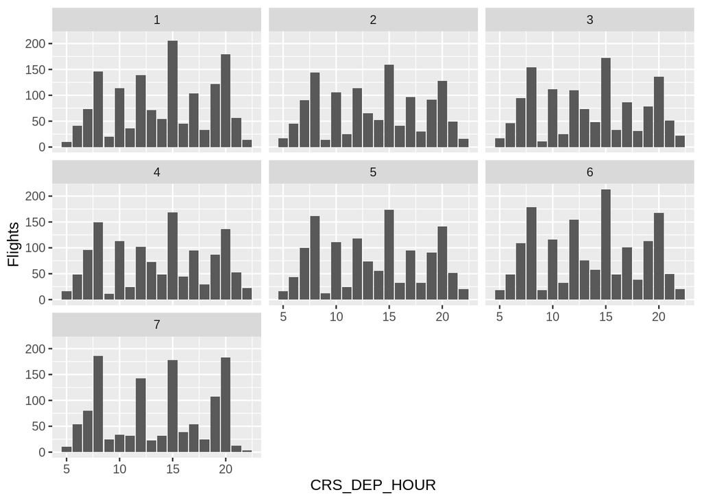

```r
ggplot(dow_hour_summary_2016_long) +
  geom_bar(aes(CRS_DEP_HOUR, Flights), stat = 'Identity') +
  facet_wrap(~ Day)
```

For the rest of the problems we are just interested in flights **out** of DTW. To make our life a little easier, let’s create a dataframe called `flights_out`.

```r
flights_out <- flights %>%
  filter(ORIGIN == 'DTW')
```

### Problem 4 - Engineer new features to facilitate time of day analysis

Remember, use the new `flights_out` dataframe for the rest of the assignment unless otherwise specified.

Create a new field showing the hour of day for the flight departure called CRS_DEP_HOUR based on CRS_DEP_TIME. Check it by displaying the first 10 rows and the CRS_DEP_HOUR and CRS_DEP_TIME fields. Use can use **dplyr** and its `mutate()` function for this problem or you can use base R commands. Even better, show how to do it both ways. HINT: We did this in class.

```r
## Add new departure hour field

flights_out$CRS_DEP_HOUR <- flights_out$CRS_DEP_TIME %/% 100

## Display first 10 rows and just the CRS_DEP_HOUR and CRS_DEP_TIME fields

flights_out[1:10, c("CRS_DEP_TIME", "CRS_DEP_HOUR") ]
```

```
##    CRS_DEP_TIME CRS_DEP_HOUR
## 1          1105           11
## 2          1207           12
## 3           850            8
## 4          2035           20
## 5          1630           16
## 6          1915           19
## 7           833            8
## 8          1211           12
## 9          1535           15
## 10         2032           20
```

In addition, you decide that you’d like to create a “coarser” version based on “departure period”. Let’s call it CRS_DEP_PRD. The values of this new variable are as follows:

1 if CRS_DEP_HOUR in [0,5] 2 if CRS_DEP_HOUR in [6,12] 3 if CRS_DEP_HOUR in [13,18] 4 if CRS_DEP_HOUR in [19,23]

See http://www.cookbook-r.com/Manipulating_data/Recoding_data/ for ideas. After creating the departure period field, makes sure you convert it to a factor if it’s not already. HINT: The `cut()` function is useful.

```r
flights_out$Departure_Period <- cut(flights_out$CRS_DEP_HOUR,
                                    breaks = c(-Inf, 5, 12, 18, Inf),
                                    labels = c(1, 2, 3, 4)
                                    )
```

Finally, create a field FL_DOW based on FL_DATE representing the day of week of the flight. The **lubridate** package will be helpful.

```r
# Create day of week field called FL_DOW
flights_out$FL_DOW <- wday(flights_out$FL_DATE)
```

### Problem 5 - Do group by analysis on CRS_DEP_PRD

Are departure delays related to departure period? Start by computing basic summary statistics for DEP_DELAY by CRS_DEP_PRD. Of course you already know how to do this from previous questions in this assignment. If you weren’t able to create CRS_DEP_PRD, then use CRS_DEP_HOUR.

Use **dplyr**.

```r
ddelay_period_summary <- flights_out %>%
  group_by(Departure_Period) %>%
  summarize(
      num_flights = n(),
      mean_delay = mean(DEP_DELAY, na.rm = TRUE),
      std_dev_delay = sd(DEP_DELAY, na.rm = TRUE),
        min_delay = min(DEP_DELAY, na.rm = TRUE),
        max_delay = max(DEP_DELAY, na.rm = TRUE),
        IQR_Delay = IQR(DEP_DELAY, na.rm = TRUE))

# these are the same thing....since we grouped by a factor with only 4 levels
head(ddelay_period_summary)
```

```
## # A tibble: 4 x 7
##   Departure_Period num_flights mean_delay std_dev_delay min_delay max_delay
##   <fct>                  <int>      <dbl>         <dbl>     <int>     <int>
## 1 1                         96       7.5           51.3       -12       351
## 2 2                       4298       9.64          41.1       -23       484
## 3 3                       3013      14.7           49.9       -19       948
## 4 4                       2276      19.3           68.4       -19       990
## # … with 1 more variable: IQR_Delay <dbl>
```

```r
tail(ddelay_period_summary)
```

```
## # A tibble: 4 x 7
##   Departure_Period num_flights mean_delay std_dev_delay min_delay max_delay
##   <fct>                  <int>      <dbl>         <dbl>     <int>     <int>
## 1 1                         96       7.5           51.3       -12       351
## 2 2                       4298       9.64          41.1       -23       484
## 3 3                       3013      14.7           49.9       -19       948
## 4 4                       2276      19.3           68.4       -19       990
## # … with 1 more variable: IQR_Delay <dbl>
```

> It sure looks like we have longer delays later in the day. The mean delay for periods 3 and 4 are 14.7 and 19.3 minutes, respectively, with some maximum delays well over 900 minutes. At what point do you just cancel a flight?

**Hacker Extra** If you’d like, make boxplots or violin plots of DEP_DELAY by CRS_DEP_PRD. They won’t be pretty. Make them easier to read.

> The stock boxplots were unreadable. The below is more useful. You still don’t get the full picture of the outliers using only boxplots, so I also put together a faceted QQ plot.. Credit “Joe” on Stack Exchange for the idea on limiting the y-coordinates: https://stackoverflow.com/questions/28198613/r-ggplot-boxplot-change-y-axis-limit/28199268 And credit Nick Cox for the idea of adding in the QQ plot. I couldn’t figure out how to plot them together in the same plot. Maybe another time…. https://stats.stackexchange.com/questions/114744/how-to-present-box-plot-with-an-extreme-outlier I tried some log transformed boxplots, but got rid of them because you lose the negative values…

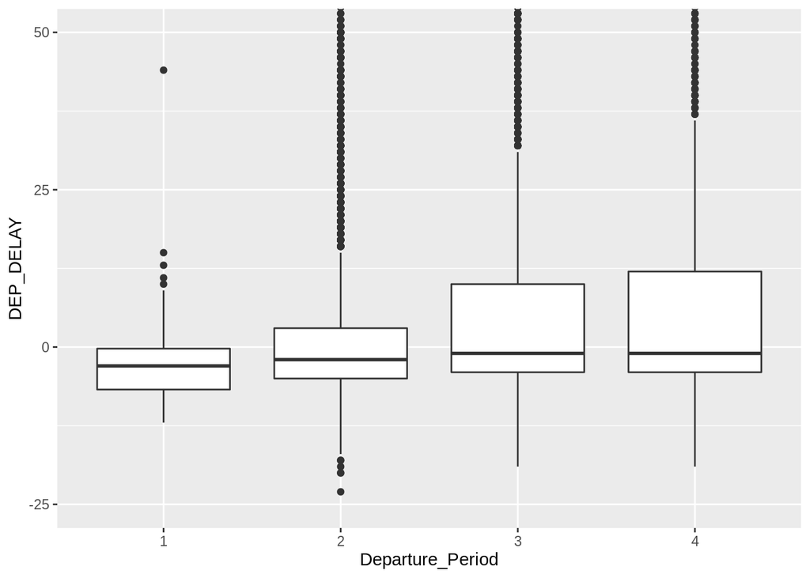

```r
# basically just zooming in
ggplot(flights_out) +
  geom_boxplot(aes(Departure_Period, DEP_DELAY)) +
  coord_cartesian(ylim = c(-25, 50))
```

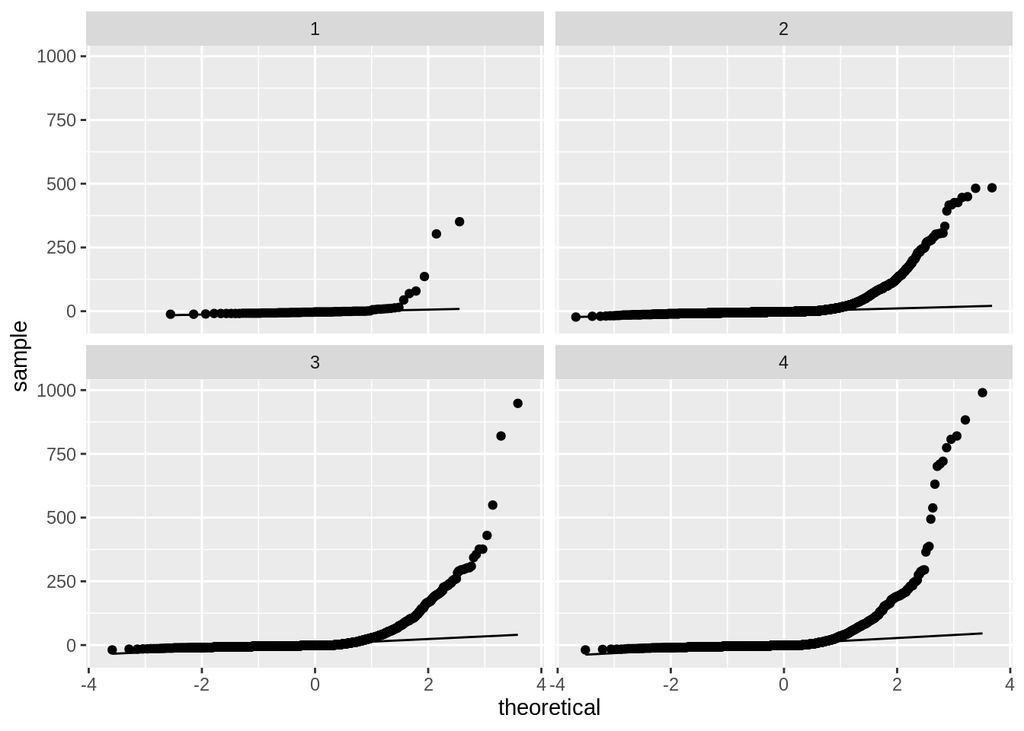

```r
# faceted QQ to add more info on the outliers
ggplot(flights_out, aes(sample = DEP_DELAY)) +
  stat_qq() +
  stat_qq_line() +
  facet_wrap(~ Departure_Period)
```

### Problem 6 - A scatterplot of DEP_DELAY by CRS_DEP_HOUR

Create two versions, a standard scatter plot and one with “jitter”.

Jitter is useful when you have many duplicate points that obscure each other.

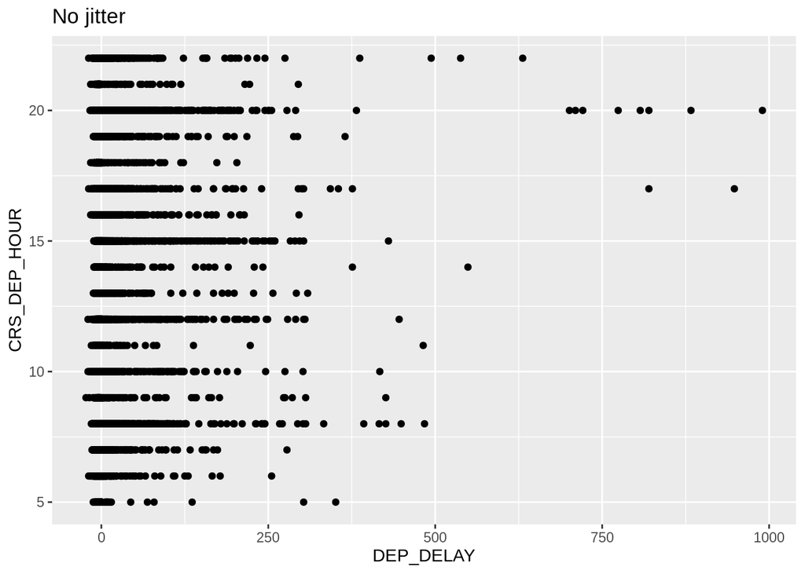

```r
ggplot(flights_out) +
  geom_point(aes(DEP_DELAY, CRS_DEP_HOUR)) +
  ggtitle("No jitter")
```

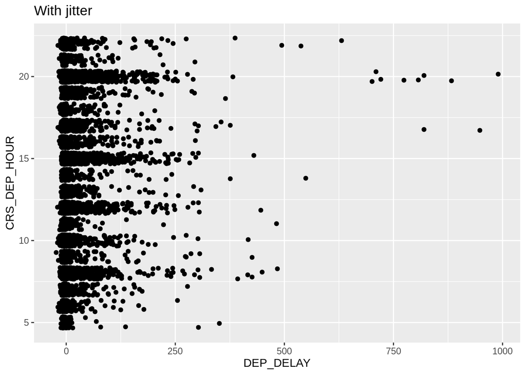

```r
ggplot(flights_out) +
  geom_point(aes(DEP_DELAY, CRS_DEP_HOUR), position = position_jitter(w = 0, h = 0.35)) +
  ggtitle("With jitter")
```

### Problem 7 - Are departure delays related to day of week?

Use plots and/or group by analysis to take a first look at these questions.

```r
DowDelaySummary <- flights_out %>%
  group_by(FL_DOW) %>%
  summarize(
    total_flights = n(),
    avg_delay = mean(DEP_DELAY, na.rm = TRUE)
  )

DowDelaySummary
```

```
## # A tibble: 7 x 3
##   FL_DOW total_flights avg_delay
##    <dbl>         <int>     <dbl>
## 1      1          1430     26.3
## 2      2          1674     14.6
## 3      3          1638     14.3
## 4      4          1323      7.76
## 5      5          1347      6.61
## 6      6          1340      9.34
## 7      7           931     14.8
```

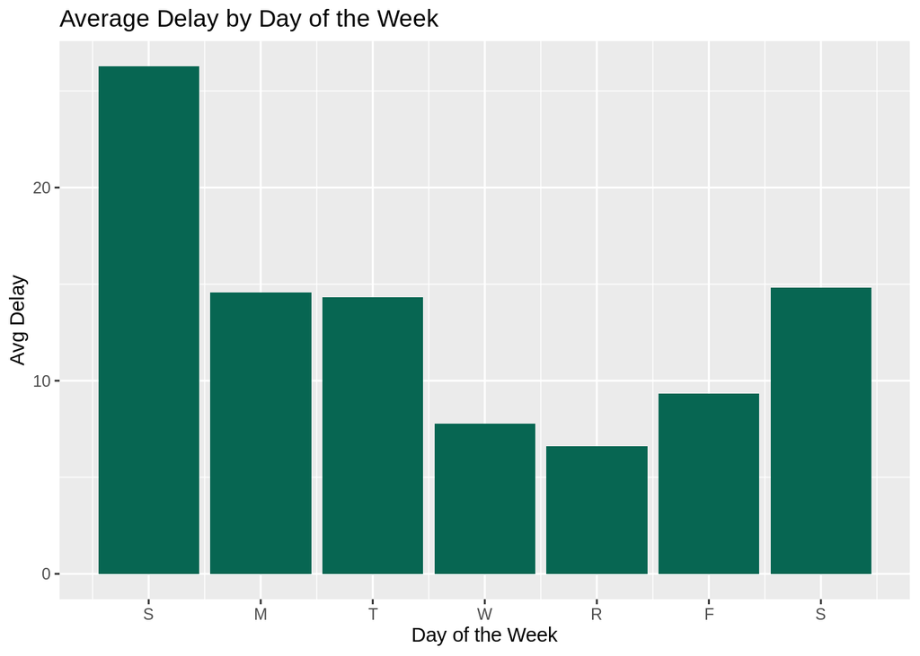

```r
# Masters Green / Adjusted labels
ggplot(DowDelaySummary) +
  geom_bar(aes(FL_DOW, avg_delay), stat = 'Identity', fill = rgb(red=7, green=102, blue=82, maxColorValue = 255)) +
  ggtitle('Average Delay by Day of the Week') +
  scale_y_continuous('Avg Delay') +
  scale_x_continuous(breaks = c(1:7), labels = c('S', 'M', 'T', 'W', 'R', 'F', 'S')) +
  xlab("Day of the Week")
```

### Problem 8 - Linear regression models

Given the limited number of fields we have and the fact that we only have one month of data, do you think we can build a linear regression model to predict DEP_DELAY that outperforms a simple null model which simply predicts the overall mean departure delay?

I’ll partition `flights_out` into a training and test set. Use the training data to build your model. Then use your model to make predictions on the test set and compute RMSE for your predictions. Compare to the RMSE I compute below for the naive null model based on just predicting overall mean delay for everyone.

```r
# Simple partition into train and test set
set.seed(447)
testrecs <- sample(nrow(flights_out), floor(0.20 * nrow(flights_out)))
flights_out_train <- flights_out[-testrecs,]
flights_out_test <- flights_out[testrecs,]

# Get rid of cancelled flights
flights_out_train <- flights_out_train %>%
  filter(CANCELLED == 0)

flights_out_test <- flights_out_test %>%
  filter(CANCELLED == 0)
```

Create our “null model” which is simply the overall mean DEP_DELAY for all the flights in the training dataset. Think of a null model as a very simple “model” that any other model better be able to beat if it’s going to be any good.

```r
null_pred <- mean(flights_out_train$DEP_DELAY)
null_pred
```

```
## [1] 13.10277
```

```r
# Load MLmetrics library to get rmse() function
library(MLmetrics)
null_rmse <- RMSE(flights_out_test$DEP_DELAY, null_pred)
null_rmse
```

```
## [1] 57.48376
```

Try to build a linear regression model to predict DEP_DELAY that has a lower RMSE than this on the test data. Feel free to create any new fields you’d like as long as you don’t include information that would not be available the day before the actual flight - i.e. we need to avoid being accidentally “clairvoyant”.

```r
# fun with linear regression
modelfit1 <- lm(DEP_DELAY ~ Departure_Period + FL_DOW, data = flights_out_train)

summary(modelfit1)
```

```
##
## Call:
## lm(formula = DEP_DELAY ~ Departure_Period + FL_DOW, data = flights_out_train)
##
## Residuals:
##    Min     1Q Median     3Q    Max
##  -41.8  -18.5  -13.2   -4.8  938.8
##
## Coefficients:
##                   Estimate Std. Error t value Pr(>|t|)
## (Intercept)        18.5411     5.8876   3.149  0.00164 **
## Departure_Period2  -1.2228     5.8349  -0.210  0.83401
## Departure_Period3   3.0792     5.8614   0.525  0.59937
## Departure_Period4   8.3861     5.8948   1.423  0.15489
## FL_DOW             -2.0616     0.2963  -6.957 3.76e-12 ***
## ---
## Signif. codes:  0 '***' 0.001 '**' 0.01 '*' 0.05 '.' 0.1 ' ' 1
##
## Residual standard error: 49.33 on 7604 degrees of freedom
## Multiple R-squared:  0.01221,    Adjusted R-squared:  0.01169
## F-statistic: 23.49 on 4 and 7604 DF,  p-value: < 2.2e-16
```

```r
modelpredict1 <- predict(modelfit1, newdata = flights_out_test)

summary(modelpredict1)
```

```
##    Min. 1st Qu.  Median    Mean 3rd Qu.    Max.
##   2.887   9.251  13.195  13.423  17.497  24.866
```

```r
modelpredict1RMSE <- RMSE(flights_out_test$DEP_DELAY, modelpredict1)
modelpredict1RMSE
```

```
## [1] 57.2302
```

> So….the first model I fit, I shouldn’t even have bothered predicting with. The P values on Departure Period were not good, which actually surprised me. Day of the Week did have a good P value, so we will keep that one. The RMSE was a wash with the null prediction.

```r
# model fitting, take 2
modelfit2 <- lm(DEP_DELAY ~ FL_DOW + CRS_DEP_HOUR + DISTANCE + CARRIER + DEST, data = flights_out_train)

summary(modelfit2)
```

```
##
## Call:
## lm(formula = DEP_DELAY ~ FL_DOW + CRS_DEP_HOUR + DISTANCE + CARRIER +
##     DEST, data = flights_out_train)
##
## Residuals:
##     Min      1Q  Median      3Q     Max
## -117.34  -18.32  -10.81   -0.72  933.53
##
## Coefficients: (1 not defined because of singularities)
##                Estimate Std. Error t value Pr(>|t|)
## (Intercept)   -8.956631  14.633781  -0.612 0.540522
## FL_DOW        -2.034239   0.293641  -6.928 4.63e-12 ***
## CRS_DEP_HOUR   0.714996   0.127854   5.592 2.32e-08 ***
## DISTANCE       0.041220   0.041495   0.993 0.320564
## CARRIERAS     15.019948  12.336610   1.218 0.223448
## CARRIERB6      8.793037   7.015688   1.253 0.210121
## CARRIERDL      9.070105   3.557544   2.550 0.010806 *
## CARRIEREV     33.326864   4.722845   7.057 1.86e-12 ***
## CARRIERF9     14.036509   6.552693   2.142 0.032218 *
## CARRIERNK      7.149227   4.015542   1.780 0.075053 .
## CARRIEROO     14.326357   4.072065   3.518 0.000437 ***
## CARRIERUA      7.205117   6.055812   1.190 0.234168
## CARRIERWN      4.312961   4.413510   0.977 0.328493
## DESTALB       -5.272666  10.750345  -0.490 0.623819
## DESTAPN        5.903016  11.840389   0.499 0.618112
## DESTATL      -17.736311  12.796674  -1.386 0.165785
## DESTATW       -6.655053  10.155677  -0.655 0.512292
## DESTAUS      -33.253962  35.511116  -0.936 0.349078
## DESTAVP        5.753960  10.190988   0.565 0.572354
## DESTAZO        1.123521  11.503354   0.098 0.922198
## DESTBDL      -19.417774  12.077362  -1.608 0.107925
## DESTBGM      -22.782385   8.991315  -2.534 0.011303 *
## DESTBHM      -14.724628  15.153767  -0.972 0.331241
## DESTBNA      -15.103980   8.509207  -1.775 0.075936 .
## DESTBOS      -18.706793  14.526841  -1.288 0.197876
## DESTBTV      -47.750469  20.078706  -2.378 0.017424 *
## DESTBUF        0.002283   7.656900   0.000 0.999762
## DESTBWI      -10.855203   7.270063  -1.493 0.135443
## DESTCAK       18.398258  11.319049   1.625 0.104114
```

[output cut: 71 more lines]

```
## DESTSJU      -78.274167  69.269334  -1.130 0.258513
## DESTSLC      -49.270009  48.770175  -1.010 0.312409
## DESTSRQ      -36.616539  35.738932  -1.025 0.305606
## DESTSTL      -19.596432   9.206633  -2.129 0.033327 *
## DESTSYR      -12.872928   7.628884  -1.687 0.091569 .
## DESTTPA      -32.633863  28.262422  -1.155 0.248261
## DESTTTN      -33.594455  35.823501  -0.938 0.348389
## DESTTUL      -42.542782  23.061735  -1.845 0.065116 .
## DESTTVC              NA         NA      NA       NA
## ---
## Signif. codes:  0 '***' 0.001 '**' 0.01 '*' 0.05 '.' 0.1 ' ' 1
##
## Residual standard error: 48.72 on 7501 degrees of freedom
## Multiple R-squared:  0.04957,    Adjusted R-squared:  0.03601
## F-statistic: 3.656 on 107 and 7501 DF,  p-value: < 2.2e-16
```

```r
# see my comments below
# modelpredict2 <- predict(modelfit2, newdata = flights_out_test)
```

> After adding DEST to the model, I receive the following error when defining modelpredict2 above: Error in model.frame.default(Terms, newdata, na.action = na.action, xlev = object$xlevels) : factor DEST has new levels CHS.

```r
# what's the deal???
filter(flights_out_train, DEST == 'CHS')
```

```
##  [1] FL_DATE             CARRIER             ORIGIN
##  [4] ORIGIN_CITY_NAME    ORIGIN_STATE_ABR    DEST
##  [7] DEST_CITY_NAME      DEST_STATE_ABR      CRS_DEP_TIME
## [10] DEP_TIME            DEP_DELAY           TAXI_OUT
## [13] WHEELS_OFF          WHEELS_ON           TAXI_IN
## [16] CRS_ARR_TIME        ARR_TIME            ARR_DELAY
## [19] CANCELLED           CANCELLATION_CODE   CRS_ELAPSED_TIME
## [22] ACTUAL_ELAPSED_TIME AIR_TIME            DISTANCE
## [25] FL_DOW              CRS_DEP_HOUR        Departure_Period
## <0 rows> (or 0-length row.names)
```

```r
filter(flights_out_test, DEST == 'CHS')
```

```
##      FL_DATE CARRIER ORIGIN ORIGIN_CITY_NAME ORIGIN_STATE_ABR DEST
## 1 2017-01-14      DL    DTW      Detroit, MI               MI  CHS
##   DEST_CITY_NAME DEST_STATE_ABR CRS_DEP_TIME DEP_TIME DEP_DELAY TAXI_OUT
## 1 Charleston, SC             SC         2025     2018        -7       18
##   WHEELS_OFF WHEELS_ON TAXI_IN CRS_ARR_TIME ARR_TIME ARR_DELAY CANCELLED
## 1       2036      2203       6         2244     2209       -35         0
##   CANCELLATION_CODE CRS_ELAPSED_TIME ACTUAL_ELAPSED_TIME AIR_TIME DISTANCE
## 1                                139                 111       87      667
##   FL_DOW CRS_DEP_HOUR Departure_Period
## 1      7           20                4
```

> I interpret this as….the training set doesn’t have an observation with CHS, so the model doens’t know what to do with the CHS destination in the test set. This has to be a common occurence in predictive modeling. How to handle? I goofed around with droplevels, but wasn’t able to get it to work. For now, I will manually remove the record where DEST = CHS and hope it works.

```r
# removing one record...
flights_out_test <- filter(flights_out_test, DEST != 'CHS')

modelpredict2 <- predict(modelfit2, newdata = flights_out_test)
summary(modelpredict2)
```

```
##    Min. 1st Qu.  Median    Mean 3rd Qu.    Max.
## -14.623   6.444  12.125  13.127  18.514 107.622
```

```r
modelpredict2RMSE <- RMSE(flights_out_test$DEP_DELAY, modelpredict2)
modelpredict2RMSE
```

```
## [1] 57.30164
```

> Okay, I got the thing to run, but I am concerned about the warning about rank-deficient fits. And my RMSE is not good. I am disappointed I don’t have a better model. But I’m not surprised since we don’t have anything weather-related in the data set. Looking forward to seeing what your take on this model was.

### Problem 9 - Bar charts

Create a basic bar chart based on number of flights by Carrier.

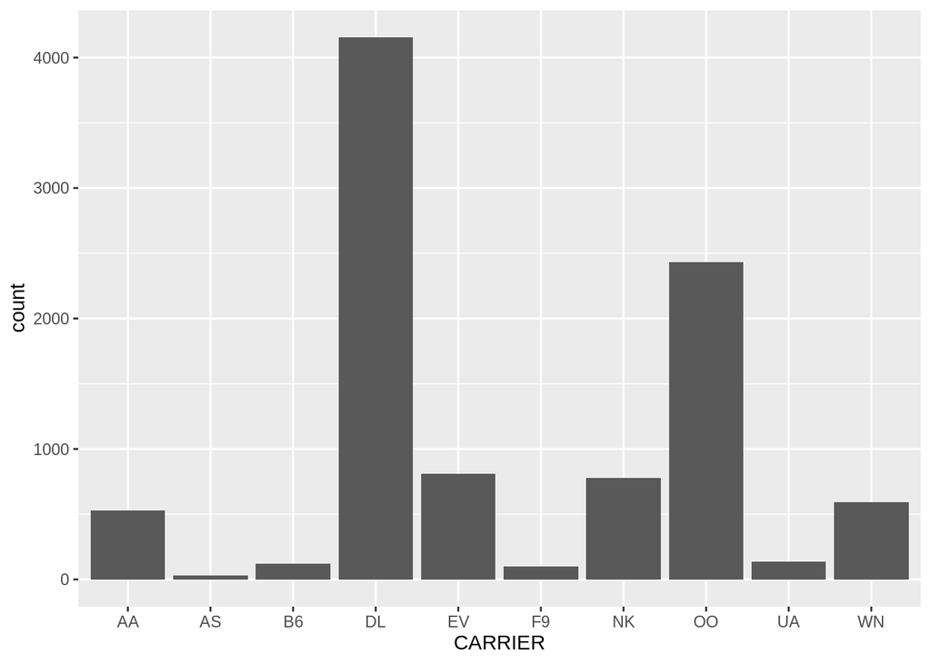

```r
ggplot(flights_out) + geom_bar(aes(x=CARRIER))
```

Now create a similar plot but instead of the bars being based on counts, make it be the mean DEP_DELAY. The key is to base your plot on the result of a **dplyr** query. Hint: You’ll also want to learn about the `stat` layer in ggplots.

This is a general strategy that is often useful for complex charts - create an intermediate dataframe that will make it “easy” to create the chart. Tools like **dplyr** (or **plyr** or **apply** family) are often a good choice for creating the intermediate dataframe.

For an additional challenge, try to order the bars so longest bars first.

Here’s what my solution looks like:

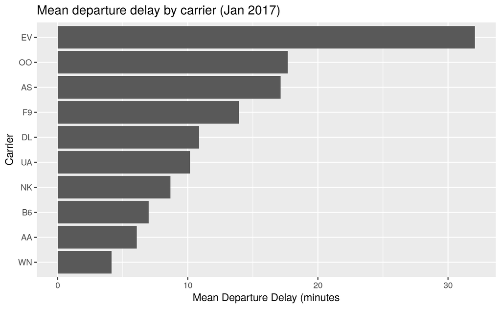

```r
knitr::include_graphics("images/mean_depdelay_carrier.png")
```

```r
# did something similar above :-)
CarrierDelaySummary <- flights_out %>%
  group_by(CARRIER) %>%
  summarize(
    total_flights = n(),
    avg_delay = mean(DEP_DELAY, na.rm = TRUE)
  )

CarrierDelaySummary
```

```
## # A tibble: 10 x 3
##    CARRIER total_flights avg_delay
##    <fct>           <int>     <dbl>
##  1 AA                531      6.08
##  2 AS                 31     17.1
##  3 B6                118      7
##  4 DL               4156     10.9
##  5 EV                812     32.1
##  6 F9                 99     13.9
##  7 NK                778      8.66
##  8 OO               2430     17.7
##  9 UA                138     10.2
## 10 WN                590      4.15
```

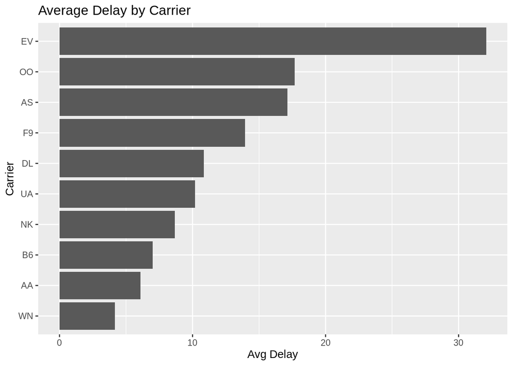

```r
ggplot(CarrierDelaySummary) +
  geom_bar(aes(reorder(CARRIER, avg_delay), avg_delay), stat = 'Identity') +
  coord_flip() +
  ggtitle('Average Delay by Carrier') +
  scale_y_continuous('Avg Delay') +
  scale_x_discrete('Carrier')
```

**Hacker Extra #1 - Faceted density plots for high volume airports**

Create faceted (by ORIGIN) density plots of DEP_DELAY for those airports having greater than 200 flights.

Here’s what my solution looks like:

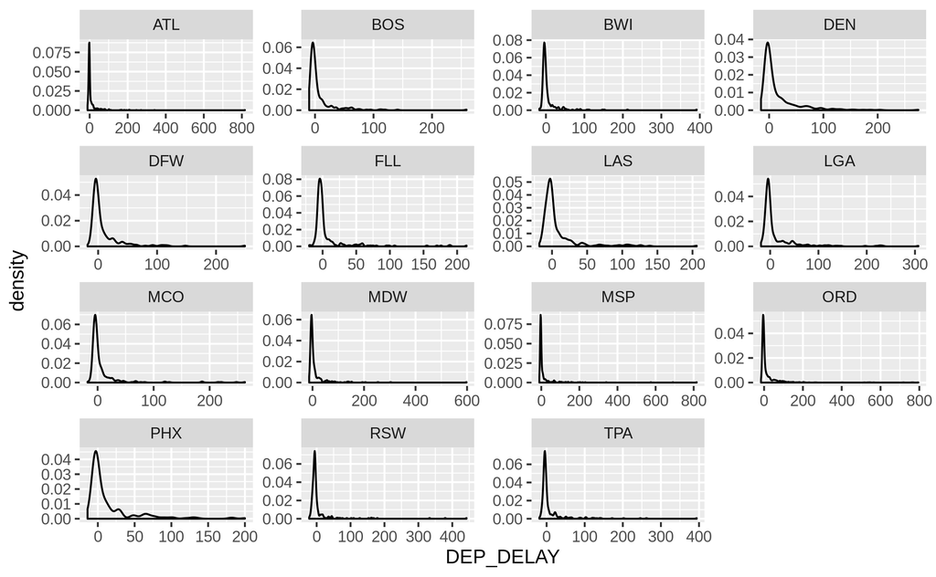

```r
knitr::include_graphics("images/depdelay_densities.png")
```

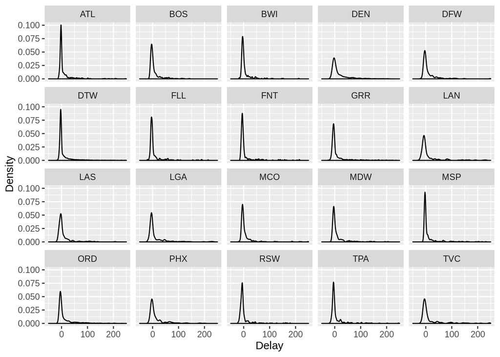

```r
sum200 <- by_orig_sum %>%
  filter(num_flights > 200)


ggplot(subset(flights, ORIGIN %in% sum200$ORIGIN)) +
  geom_density(aes(DEP_DELAY)) +
  facet_wrap(~ ORIGIN) +
  scale_x_continuous(name = 'Delay', limits = c(-50, 250)) +
  ylab('Density')
```

```r
# double-check that DTW has more than 200 outbound flights.  I commented this out just to clean up the HTML.
# flights %>%
#   filter(ORIGIN == 'DTW')
```

> My results are clearly different than the example provided. I have 20 airports here. I doubled checked the code, and believe I did this correctly. I’m not sure if I used the wrong data-set, or otherwise did something to the flights data frame to mess it up. Fingers crossed….

### Hacker Extra -#2 - Average number of flights by day of week by carrier

Compute the average number of flights by day of week by carrier. Be careful - you must make sure that your solution works even if some carrier has a date on which they have no flights. Here’s what my solution looks like.

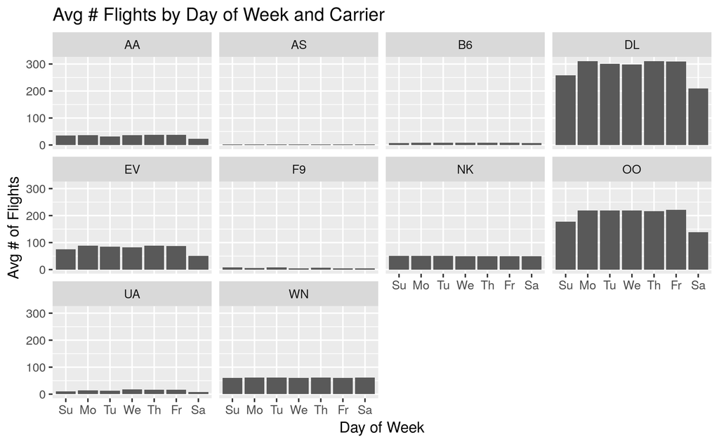

```r
knitr::include_graphics("images/flights_carrier_dow.png")
```

> I ended up creating multiple new data frames and using lubridate functions to get the average flights by day of the week. Seemed like a lot of work, but I was victorious in the end.

```r
# check dates in the data set
startdate <- min(flights$FL_DATE)
enddate <- max(flights$FL_DATE)

# create a data frame of dates & corresponding days of the week in the flights data set
# but first get the vector of dates from Jan 2017
num_days <- interval(startdate, enddate)/days(1)
dates <- startdate + days(0: num_days)
datesdf <- data.frame(dates)
datesdf$dayofweek <- wday(datesdf$dates)

# pivot
datesdf <- datesdf %>%
  group_by(dayofweek) %>%
  summarize(count_jan_days = n())

# now summarize flights by carrier and day of week
flightsdf <- data.frame(flights %>%
  group_by(CARRIER, FL_DOW) %>%
  summarize(
    totflights = n()
    ))

# now I have all the data needed....hopefully
joindf <- left_join(flightsdf, datesdf, by = c('FL_DOW' = 'dayofweek'))
joindf$avgdays <- joindf$totflights / joindf$count_jan_days

joindf
```

```
##    CARRIER FL_DOW totflights count_jan_days avgdays
## 1       AA      1        174              5   34.80
## 2       AA      2        185              5   37.00
## 3       AA      3        158              5   31.60
## 4       AA      4        147              4   36.75
## 5       AA      5        152              4   38.00
## 6       AA      6        152              4   38.00
## 7       AA      7         94              4   23.50
## 8       AS      1         10              5    2.00
## 9       AS      2         10              5    2.00
## 10      AS      3         10              5    2.00
## 11      AS      4          8              4    2.00
## 12      AS      5          8              4    2.00
## 13      AS      6          8              4    2.00
## 14      AS      7          8              4    2.00
```

[output cut: 56 more lines]

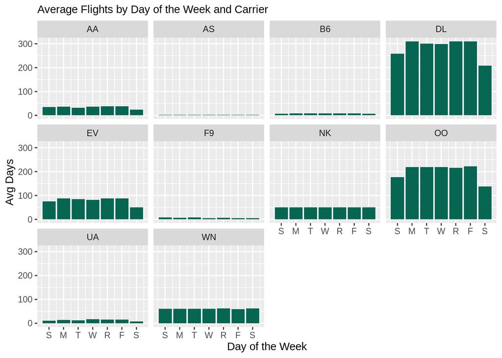

```r
# note: adding in the ggtitle makes Carrier 'AS' appear to go null for some reason.
# Shrinking the font size seemed to help, so I assume it was just a visualization issue
ggplot(joindf) +
  geom_bar(aes(FL_DOW, avgdays), stat = 'Identity', fill = rgb(red=7, green=102, blue=82, maxColorValue = 255)) +
  facet_wrap(~ CARRIER) +
  scale_x_continuous(breaks = c(1:7), labels = c('S', 'M', 'T', 'W', 'R', 'F', 'S')) +
  xlab('Day of the Week') +
  ylab('Avg Days') +
  ggtitle('Average Flights by Day of the Week and Carrier') +
  theme(plot.title = element_text(size=11))
```

> Check out my github repo: https://github.com/KSalach/PCDA-REPO

## Deliverables

Make sure all of your files are closed and saved and are inside your R project folder. Compress that entire folder and upload it via Moodle.